# Introduction

In a problem of location, we seek to find the optimal location of a service, or a set of them, so that the quality that the service provides to a set of demand points is, according to a given performance measure, optimal. Some examples of localization problems are:

- Find the optimal location of the central warehouse of a merchandise distribution network so that the total cost of transport is minimized
- Find the optimal location of an ambulance that must attend to the patients of a certain region so that the time in treating the farthest patient is minimized

There are numerous contexts in which localization problems arise, due to this, the location theory has been object of great attention in recent years, being able to say that it is a subject of great importance. The appearance of new facets of the problem didn't handle until now contributes to this. For example, along with the already classic criteria for minimizing costs, new criteria appear: environmental, social, quality of life, etc. These new aspects of the problem make it an open field of study.

The package presented is devoted to solving the problem of locating a single point in the plane, using as an objective the minimization of the sum of the weighted distances to the demand points. New versions of the package will include new location models.

# The class of objects loca.p

In a planar location problem, the set of demand points is given by the coordinates of said points. Optionally, a weighting can be assigned to said points, which gives more importance to some points than to others, since the objective considered is to minimize the weighted sum of the distances between the service point and said requesting assembly. For example, if the location of a regional hospital is sought, the demand points can be the towns to which the hospital must attend and the weights of the population of each locality.

The rest of this section will explain how to do basic operations with loca.p objects.

## Creating class objects loca.p

Consider a location problem in which the set of demand points is \((0,0)\), \((4,0)\) and \((2,2)\). To create a `loca.p` object that represents that set, it can be done by calling the constructor function using the vector with the coordinates \(x\) and the vector with the \(y\) coordinates of the set of points as arguments:

```r
loca.p(c(0, 4, 2), c(0, 0, 2))
```

```
#> An object of class "loca.p"
#> Slot "x":
#> [1] 0 4 2
#>
#> Slot "y":
#> [1] 0 0 2
#>
#> Slot "w":
#> [1] 1 1 1
#>
#> Slot "label":
#> [1] ""
```

or alternatively:

```r
loca.p(x = c(0, 4, 2), y = c(0, 0, 2))
```

The constructor has two more optional arguments, the third `w` is used to specify a vector of weights and the fourth to specify a label that will be used to identify the object. If, using the same set of points, we want to assign the weights 1, 1, 3, to said points and the label “Problem 1”, we use:

```r
loca.p(x = c(0, 4, 2), y = c(0, 0, 2), w = c(1, 1, 3), label = "Problem 1")
```

```
#> An object of class "loca.p"
#> Slot "x":
#> [1] 0 4 2
#>
#> Slot "y":
#> [1] 0 0 2
#>
#> Slot "w":
#> [1] 1 1 3
#>
#> Slot "label":
#> [1] "Problem 1"
```

A `loca.p` object can also be obtained by converting a `data.frame` object that has the `x` and `y` columns, and optionally `w`. Starting from `data.frame`

```r
d
```

```
#>    x y w
#> 1  0 0 1
#> 2 10 0 3
#> 3  2 8 1
```

you can build a `loca.p` object by calling the `as` function:

```r
as(d, "loca.p")
```

```
#> An object of class "loca.p"
#> Slot "x":
#> [1]  0 10  2
#>
#> Slot "y":
#> [1] 0 0 8
#>
#> Slot "w":
#> [1] 1 3 1
#>
#> Slot "label":
#> [1] ""
```

or alternatively:

```r
as.loca.p(d)
```

Reciprocally, a `loca.p` object can be converted into a `data.frame` object by:

```r
p1 <- loca.p(x = c(0, 4, 2), y = c(0, 0, 2), w = c(1, 1, 3), label = "Problem 1")
as(p1, 'data.frame')
```

```
#>   w x y
#> 1 1 0 0
#> 2 1 4 0
#> 3 3 2 2
```

or alternatively

```r
as.data.frame(p1)
```

In conversions, the `label` slot of the `loca.p` object is stored as an attribute of the `data.frame` object. The label can be read and modified by accessing them:

```r
p1@label
```

```
#> [1] "Problem 1"
```

```r
dp1 <- as.data.frame(p1)
attr(dp1, "label")
```

```
#> [1] "Problem 1"
```

The `loca.p` objects can also be transformed into or constructed from objects of type `matrix`.

## Random generation of class objects loca.p

Random objects of class `loca.p` can be created using the `rloca.p` function. The first argument, `n` indicates the number of points to generate. By default, these points are generated in the unit square \([0,1] \times [0, 1]\). Thus, to generate a `loca.p` object with 5 points in the unit square, we use:

```r
set.seed(161236)
rloca.p(5)
```

```
#> An object of class "loca.p"
#> Slot "x":
#> [1] 0.12405385 0.50263749 0.15097058 0.02051109 0.57587429
#>
#> Slot "y":
#> [1] 0.2435999 0.5788917 0.7562588 0.1144796 0.2721178
#>
#> Slot "w":
#> [1] 1 1 1 1 1
#>
#> Slot "label":
#> [1] ""
```

The arguments `xmin`, `xmax`, `ymin` and `ymax` allow you to specify the rectangle in which the points will be generated. In addition, the `rloca.p` function allows you to specify the label for the new object. For example, to generate the points in the rectangle \([- 1, 1] \times[-5,5]\) with the label “Rectangle” is used:

```r
rloca.p(5, xmin = -1, xmax = 1, ymin = -5, ymax = 5, label = "Rectangle")
```

```
#> An object of class "loca.p"
#> Slot "x":
#> [1] -0.9452062  0.5769137  0.8819392 -0.6214939 -0.1391079
#>
#> Slot "y":
#> [1] -3.325587  3.931197 -4.497122 -1.304617 -2.815923
#>
#> Slot "w":
#> [1] 1 1 1 1 1
#>
#> Slot "label":
#> [1] "Rectangle"
```

The points generated by the `rloca.p` function can be generated in spatially distributed groups. The `groups` argument allows you to specify the number of groups by a number or the number of points in each group through a vector. In this second case, the value given to the `n` argument is ignored. To randomly generate a demand set with three equal groups:

```r
rloca.p(9, groups = 3, label = "Three equal groups")
```

```
#> An object of class "loca.p"
#> Slot "x":
#> [1] 1.0435201 1.1954117 1.6470744 0.7868431 0.7648655 0.8508291 0.7502594
#> [8] 1.0788618 1.1116052
#>
#> Slot "y":
#> [1] 1.1400092 0.6076905 0.8163944 1.3954599 1.3186699 0.9262516 0.9044921
#> [8] 0.9464590 0.7384576
#>
#> Slot "w":
#> [1] 1 1 1 1 1 1 1 1 1
#>
#> Slot "label":
#> [1] "Three equal groups"
```

for three unequal groups:

```r
rloca.p(groups = c(2, 2, 5), label = "Three unequal groups")
```

```
#> An object of class "loca.p"
#> Slot "x":
#> [1] 1.6689680 0.9978501 0.5592493 0.4330953 0.7297446 1.1752629 0.9298473
#> [8] 0.4017964 0.8527443
#>
#> Slot "y":
#> [1] 0.9097321 0.4319344 1.4223225 1.4137017 0.5544933 1.2903588 0.4965480
#> [8] 1.0362726 0.4947184
#>
#> Slot "w":
#> [1] 1 1 1 1 1 1 1 1 1
#>
#> Slot "label":
#> [1] "Three unequal groups"
```

To generate the data in groups, an offset of the center of each group is generated first and then the points are generated by adding to each point the offset that corresponds to their group. For this reason, `groups = 1` is not equivalent to not specifying that parameter. The offset of the centers can be specified by the arguments `xgmin`, `xgmax`, `ygmin` and `ygmax`. To illustrate better how the function works, the result can be painted:

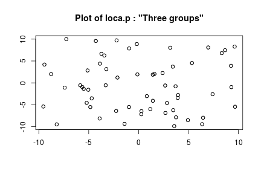

```r
rl <- rloca.p(60, groups = 3, xmin = -10, xmax = 10, ymin = -10, ymax = 10, xgmin = -1, xgmax = 1, ygmin = -1, ygmax = 1, label = "Three groups")
plot(rl)
```

## Summaring up the data

To obtain a numeric summary of a `loca.p` object you can use the `summary` function:

```r
summary(rl)
```

```
#>               label                   n                xmin              xwmean
#>      "Three groups"                "60" "-9.54649574030191" "0.172239909491812"
#>                xmax                ymin              ywmean                ymax
#>  "9.66257251426578" "-9.88218353176489" "-0.55051479760247"  "9.99047618778422"
```

# Weighted average distance

Given a `loca.p` object, we can evaluate the weighted distance from a given point. Likewise, the gradient of said function can be evaluated and the problem of minimizing said objective can be solved.

## Evaluation

The weighted average distance function is called `distsum` in the package, given a point, for example: \((3, 1)\) you can evaluate the weighted average distance to a `loca.p` object:

```r
pt3 <- loca.p(x = c(0, 4, 2), y = c(0, 0, 2), label = "Three points")
distsum(o = pt3, x = 3, y = 1)
```

```
#> [1] 5.990705
```

You can also calculate the gradient of `distsum` called `distsumgra`:

```r
distsumgra(o = pt3, x = 3, y = 1)
```

```
#> [1] 0.9486833 0.3162278
```

## Resolution

To find the optimal solution to the previous location problem, use the `distsummin` function:

```r
s <- distsummin(pt3)
s
```

```
#> [1] 2.00000 1.15332
```

Evaluating the function and the gradient at the point obtained

```r
distsum(o = pt3, x = s[1], y = s[2])
```

```
#> [1] 5.464102
```

```r
distsumgra(o = pt3, x = s[1], y = s[2])
```

```
#> [1]  3.110246e-07 -8.970172e-04
```

As can be verified by the value of the gradient, the solution found is a local optimum and, since the convex objective function, is a global optimum.

These three functions support an optional `lp` argument, if this argument is omitted, the Euclidean standard is used, that is, the \(l_2\) rule, if a value is specified for `lp` the \(l_p\) rule will be used for that value of \(p\).

Note that specifying `lp = 2` uses the generic algorithm for the `l_p` rule with \(p\) equal to 2. The use of the generic algorithm requires a greater computational effort to solve the problem, so it is not advisable to specify this argument to use the Euclidean norm.

# Plotting

Both the `loca.p` objects and the objective function can be plotted in a graph. For the objective function a representation based on level curves and another on a 3D graph is provided.

## Plot an object `loca.p`

The graph of a `loca.p` object consists of plotting the scatter plot of the set of demand points in the plane using the plot function:

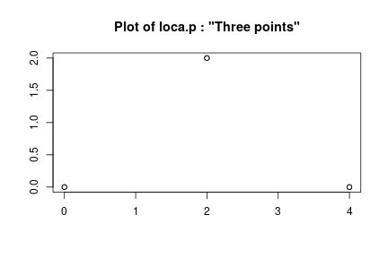

```r
plot(pt3)
```

## Contour graph

The contour graph is made with the `contour` function:

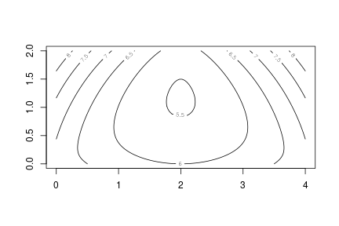

```r
contour(pt3)
```

In the graph you can see how the function reaches the minimum at the point previously calculated. Expanding:

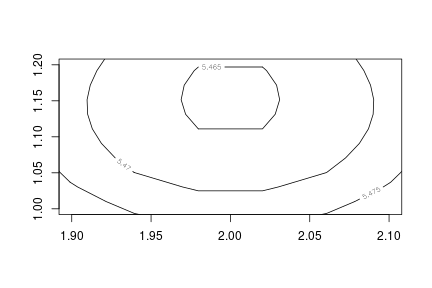

```r
contour(pt3, xlim = c(1.9, 2.1), ylim = c(1, 1.2), levels = c(5.465, 5.47, 5.475))
```

The `plot` and `contour` functions support an optional `img` argument that allows you to specify a raster graphic to be used as the background of the graphic.

## 3D graph

Analogously, a three-dimensional representation can be made using the `persp` function:

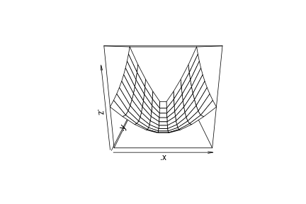

```r
persp(pt3)
```

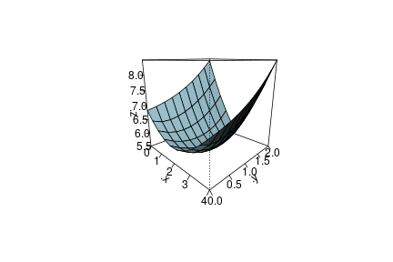

```r
persp(pt3, col = "lightblue", theta = 45, ltheta = 120, shade = 0.75, ticktype = "detailed")
```

The three representation functions will pass the remaining optional arguments to the generic function plot.

## Example of location in Andalusia

The data of the Andalusian capitals are loaded and it becomes a class object `loca.p`:

```r
data(andalusia)
o <- loca.p(x = andalusia$x[1: 8], y = andalusia$y[1: 8])
```

The bounds values for the graph are calculated:

```r
xmin <- min(andalusia$x)
ymin <- min(andalusia$y)
xmax <- max(andalusia$x)
ymax <- max(andalusia$y)
```

The map of Andalusia is loaded and the points are represented with the background map

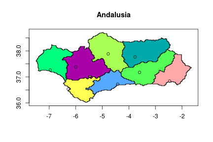

```r
file = system.file('img', 'andalusian_provinces.png', package = 'orloca')
img = readPNG(file)
plot(o, img = img, main = 'Andalusia', xleft = xmin, ybottom = ymin, xright = xmax, ytop = ymax)
```

The contour graph is:

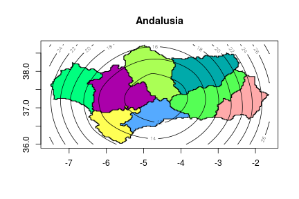

```r
contour(o, img = img, main = 'Andalusia', xleft = xmin, ybottom = ymin, xright = xmax, ytop = ymax)
```

The optimal solution of the location problem with the 8 capitals, eight first rows, is obtained:

```r
andalusia.loca.p <- loca.p(andalusia$x[1: 8], andalusia$y[1: 8])
sol <- distsummin(andalusia.loca.p)
sol
```

```
#> [1] -4.610679 37.248691
```

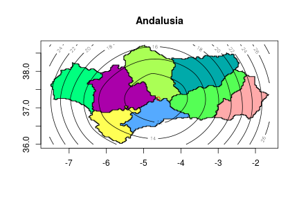

```r
contour(o, img = img, main = 'Andalusia', xleft = xmin, ybottom = ymin, xright = xmax, ytop = ymax)
points(sol[1], sol[2], type = 'p', col = 'red')
```

For simplicity in the example, the terrestrial curvature has not been taken into account.